# La cultura política y el apoyo a la democracia en Chile durante 2021

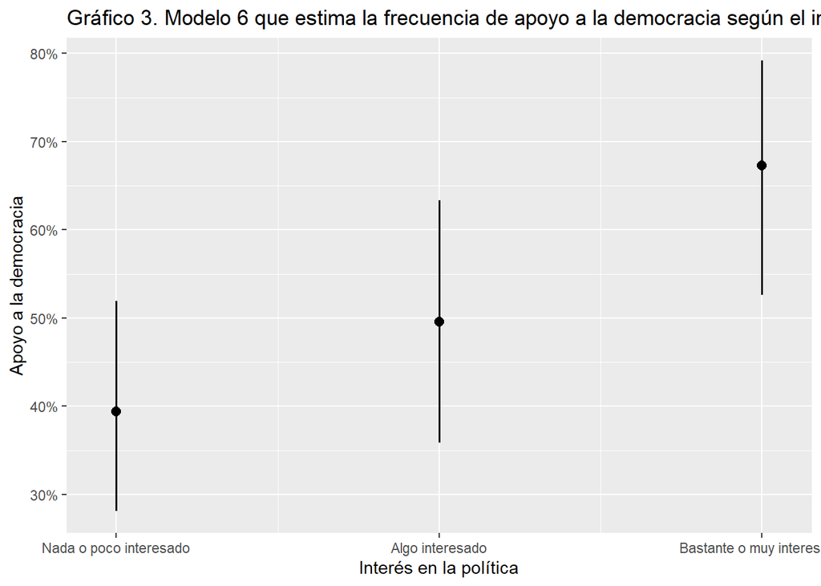

[figure not shown]

[figure not shown]

# 16. Comparación y reporte estimación modelo 6 con R base y modelo 6 con diseño muestral complejo

### Reporte con summary de modelo 6 con R base

## 16.1 Reporte de modelo *sin* pesos muestrales

```
##
## Call:
## glm(formula = apoyo_dem_dic ~ sexo + edad_tramo + nivel_educ +
##     interes_politica + confianza_pp + satis_dem, family = "binomial",
##     data = datos_proc)
##
## Deviance Residuals:
##    Min      1Q  Median      3Q     Max
## -2,319  -1,055   0,496   1,098   1,523
##
## Coefficients:
##                                           Estimate Std. Error z value Pr(>|z|)
## (Intercept)                                 -0,429      0,259   -1,66   0,0967
## sexoMujer                                   -0,212      0,113   -1,87   0,0609
## edad_tramoAdulto                            -0,141      0,211   -0,67   0,5041
## edad_tramoAdulto mayor                       0,221      0,246    0,90   0,3691
## nivel_educSecundaria                         0,276      0,149    1,85   0,0639
## nivel_educEducación técnica                  0,787      0,186    4,22  2,4e-05
## nivel_educUniversitaria o posgrado           1,452      0,202    7,20  6,0e-13
## interes_politicaAlgo interesado              0,413      0,142    2,90   0,0037
## interes_politicaBastante o muy interesado    1,152      0,192    5,99  2,1e-09
## confianza_ppAlgo                            -0,140      0,221   -0,63   0,5272
## confianza_ppBastante o mucha                 0,453      0,683    0,66   0,5079
## satis_demAlgo satisfecho                     0,211      0,129    1,63   0,1034
## satis_demBastante o muy satisfecho           0,584      0,250    2,34   0,0192
##
## (Intercept)                               .
## sexoMujer                                 .
## edad_tramoAdulto
## edad_tramoAdulto mayor
## nivel_educSecundaria                      .
## nivel_educEducación técnica               ***
## nivel_educUniversitaria o posgrado        ***
## interes_politicaAlgo interesado           **
## interes_politicaBastante o muy interesado ***
## confianza_ppAlgo
## confianza_ppBastante o mucha
## satis_demAlgo satisfecho
## satis_demBastante o muy satisfecho        *
## ---
## Signif. codes:  0 '***' 0,001 '**' 0,01 '*' 0,05 '.' 0,1 ' ' 1
##
## (Dispersion parameter for binomial family taken to be 1)
##
##     Null deviance: 2166,1  on 1572  degrees of freedom
## Residual deviance: 1963,7  on 1560  degrees of freedom
## AIC: 1990
##
## Number of Fisher Scoring iterations: 4
```

## 17.2 Reporte de modelo 6survey *con* pesos muestrales

```
##
## Call:
## svyglm(formula = apoyo_dem_dic ~ sexo + edad_tramo + nivel_educ +
##     interes_politica + confianza_pp + satis_dem, design = esi_design,
##     family = binomial(link = "logit"))
##
## Survey design:
## Called via srvyr
##
## Coefficients:
##                                           Estimate Std. Error t value Pr(>|t|)
## (Intercept)                                -0,1740     0,4108   -0,42  0,67186
## sexoMujer                                  -0,1162     0,1920   -0,61  0,54525
## edad_tramoAdulto                           -0,2566     0,3224   -0,80  0,42627
## edad_tramoAdulto mayor                     -0,0367     0,3816   -0,10  0,92346
## nivel_educSecundaria                        0,2554     0,2511    1,02  0,30938
## nivel_educEducación técnica                 0,6575     0,2965    2,22  0,02672
## nivel_educUniversitaria o posgrado          1,3205     0,3287    4,02  6,2e-05
## interes_politicaAlgo interesado             0,3011     0,2431    1,24  0,21560
## interes_politicaBastante o muy interesado   1,1852     0,3055    3,88  0,00011
## confianza_ppAlgo                           -0,2896     0,3979   -0,73  0,46678
## confianza_ppBastante o mucha                1,3892     0,7777    1,79  0,07424
## satis_demAlgo satisfecho                    0,3421     0,2603    1,31  0,18890
## satis_demBastante o muy satisfecho          0,4164     0,3722    1,12  0,26351
##
## (Intercept)
## sexoMujer
## edad_tramoAdulto
## edad_tramoAdulto mayor
## nivel_educSecundaria
## nivel_educEducación técnica               *
## nivel_educUniversitaria o posgrado        ***
## interes_politicaAlgo interesado
## interes_politicaBastante o muy interesado ***
## confianza_ppAlgo
## confianza_ppBastante o mucha              .
## satis_demAlgo satisfecho
## satis_demBastante o muy satisfecho
## ---
## Signif. codes:  0 '***' 0,001 '**' 0,01 '*' 0,05 '.' 0,1 ' ' 1
##
## (Dispersion parameter for binomial family taken to be 1)
##
## Number of Fisher Scoring iterations: 4
```

## 18. Reporte con tab_model de modelo 6 con R base y modelo6survey con diseño complejo

## 17.4 Se reporta la tabla del modelo 6 con R base:

Predictores

ß

(Intercept)

0.65

Sexo del entrevistada/o:  
Mujer

0.81

Edad por tramo: Adulto

0.87

Edad por tramo: Adulto  
mayor

1.25

Nivel educacional:  
Secundaria

1.32

Nivel educacional:  
Educación técnica

2.20 ***

Nivel educacional:  
Universitaria o posgrado

4.27 ***

¿Qué tan interesado está  
usted en la política?:  
Algo interesado

1.51 **

¿Qué tan interesado está  
usted en la política?:  
Bastante o muy interesado

3.16 ***

Grado de confianza: Los  
Partidos Politicos: Algo

0.87

Grado de confianza: Los  
Partidos Politicos:  
Bastante o mucha

1.57

¿Cuán satisfecho o  
insatisfecho está usted  
con el funcionamiento de  
la democracia en Chile?:  
Algo satisfecho

1.23

¿Cuán satisfecho o  
insatisfecho está usted  
con el funcionamiento de  
la democracia en Chile?:  
Bastante o muy satisfecho

1.79 *

Observations

1573

R<sup>2</sup> Tjur

0.119

- p<0,05 ** p<0,01 *** p<0,001

## 17.4 Se reporta la tabla del modelo 6 con diseño muestral complejo para comparación

Modelo 6 diseno complejo

Predictores

ß

(Intercept)

0.84

Sexo del entrevistada/o:  
Mujer

0.89

Edad por tramo: Adulto

0.77

Edad por tramo: Adulto  
mayor

0.96

Nivel educacional:  
Secundaria

1.29

Nivel educacional:  
Educación técnica

1.93 *

Nivel educacional:  
Universitaria o posgrado

3.75 ***

¿Qué tan interesado está  
usted en la política?:  
Algo interesado

1.35

¿Qué tan interesado está  
usted en la política?:  
Bastante o muy interesado

3.27 ***

Grado de confianza: Los  
Partidos Politicos: Algo

0.75

Grado de confianza: Los  
Partidos Politicos:  
Bastante o mucha

4.01

¿Cuán satisfecho o  
insatisfecho está usted  
con el funcionamiento de  
la democracia en Chile?:  
Algo satisfecho

1.41

¿Cuán satisfecho o  
insatisfecho está usted  
con el funcionamiento de  
la democracia en Chile?:  
Bastante o muy satisfecho

1.52

Observations

1573

R<sup>2</sup> / R<sup>2</sup> adjusted

0.085 / 0.078

- p<0,05 ** p<0,01 *** p<0,001

[figure not shown]